# 308.5. Image stamps

For the Rubin Science Platform at data.lsst.cloud.  
Data Release: [Data Preview 1](https://dp1.lsst.io/)  
Container Size: large  
LSST Science Pipelines version: r29.2.0  
Last verified to run: 2026-06-16  
Repository: github.com/lsst/tutorial-notebooks

**Learning objective:** Generate many (bulk) image stamps for Solar System objects using the Rubin image cutout service.

**LSST data products:** `DiaObject`, `SSObject`, `MPCORB`, `Visit`, `visit_image`, `template_coadd`, `difference_image`

**Packages:** `matplotlib`, `numpy`, `lsst.rsp`,`lsst.afw`, `lsst.geom`, `lsst.resources`, `lsst.utils.plotting`, `pyvo.dal.adhoc`, `reproject`

**Credit:** Originally developed by the Rubin Community Science team. Please consider acknowledging them if this notebook is used for the preparation of journal articles, software releases, or other notebooks.

**Get Support:** Everyone is encouraged to ask questions or raise issues in the [Support Category](https://community.lsst.org/c/support) of the Rubin Community Forum. Rubin staff will respond to all questions posted there.

## 1. Introduction

This notebook demonstrates how to produce bulk image stamps for Solar System objects using the Rubin cutout service. This notebook differs from the 103-series notebooks on image access and display by demonstrating how to generate cutouts for objects that move to different ra and dec positions across each detection.

**Related tutorials**: See also tutorial notebook 103.9 on image stamps, which demonstrates how to perform bulk cutouts using the cutout service that returns only the image extension to minimize the data transferred and tutorial notebook 103.4 that demonstrates the return of exposure cutouts as Rubin LSST image type `ExposureF` and `MaskedImageF`. Both of these notebooks retrieve image stamps for a single ra and dec.

### 1.1. Import packages

Import `numpy`, a fundamental package for scientific computing with arrays in Python (numpy.org), and `matplotlib`, a comprehensive library for data visualization ([matplotlib.org](https://matplotlib.org/); [matplotlib gallery](https://matplotlib.org/stable/gallery/index.html)).

From the `lsst` package, import modules for accessing the Table Access Protocol (TAP) service, image display functions, and the Simple Image Access (SIA) service from the LSST Science Pipelines ([pipelines.lsst.io](https://pipelines.lsst.io/)).

Functions from `pyvo` are imported to perform and parse results from Datalink and SODA queries. This is used to obtain images from the SIA service.

The `reproject` package is an `astropy`-adjacent package that provides access to coordinate transformations between images with world coordinate systems (WCS), and will be used to align visit images with different WCS.

```python
import math
import pandas as pd
import numpy as np
import io
import getpass
import glob
import os
import shutil
import matplotlib.pyplot as plt
import matplotlib.image as mpimg

from lsst.rsp import get_tap_service
from lsst.rsp.service import get_siav2_service
from lsst.rsp.utils import get_pyvo_auth

import lsst.afw.display as afwDisplay
from lsst.afw.image import ExposureF, ImageF
from lsst.afw.fits import MemFileManager

from pyvo.dal.adhoc import DatalinkResults, SodaQuery

from astropy import units as u
from astropy.wcs import WCS
from astropy.io import fits

from reproject import reproject_interp

from IPython.display import Image as dimg
from PIL import Image
```

### 1.2. Define parameters and functions

Create an instance of the TAP service, and assert that it exists.

```python
service = get_tap_service("tap")
assert service is not None
```

Instantiate the Simple Image Access service (SIA).

```python
sia_service = get_siav2_service("dp1")
assert sia_service is not None
```

Set the `afwDisplay` package backend to `matplotlib`.

```python
afwDisplay.setDefaultBackend('matplotlib')
```

#### 1.2.1. Set up a temporary directory

The Rubin cutout service allows the user to save many image stamps as fits files locally on the Rubin Science Platform (RSP).

RSP users should save temporary files in the shared scratch directory, `/deleted-sundays/`, in sub-directories named with their RSP username.

Get the username and ensure an appropriate `/deleted-sundays/` sub-directory exists.

```python
username = getpass.getuser()
print('username: ', username)

userdir = '/deleted-sundays/' + username
if not os.path.exists(userdir):
    os.makedirs(userdir)
    print('Created ', userdir)
else:
    print('Directory already existed: ', userdir)
```

```
username:  sarahgreenstreet
Directory already existed:  /deleted-sundays/sarahgreenstreet
```

Within that folder, create a sub-folder named `dp1_308_5_temp` in which to save files created by this tutorial. At the end of the notebook, the last cell will clear the contents and remove this temporary folder.

```python
tempdir = userdir + '/dp1_308_5_temp'
if not os.path.exists(tempdir):
    os.makedirs(tempdir)
    print('Created ', tempdir)
else:
    print('Directory already existed: ', tempdir)
```

```
Directory already existed:  /deleted-sundays/sarahgreenstreet/dp1_308_5_temp
```

Delete the `username` and `userdir`, but keep `tempdir` to be used.

```python
del username, userdir
```

#### 1.2.2. Generate a gif from pngs

The function below will generate a gif to visualize all of the image stamp files in png format produced in the notebook.

```python
def make_gif(folder):
    """
    Generate a GIF for all *.png images contained in a folder

    Parameters
    ----------
    folder : 'string'
        string containing the path to the folder
        default filename is animation.gif

    Returns
    -------
    """
    frames = [Image.open(img) for img in sorted(glob.glob(f"{folder}/*.png"))]
    frame_one = frames[0]
    frame_one.save(folder+"/animation.gif", format="GIF",
                   append_images=frames, save_all=True, duration=500, loop=1)
```

#### 1.2.3. Generate cutouts

Define a function to get an image cutout from the cutout service.

```python
def get_cutout(dl_result, ra, dec, session, fov):
    """
    Wrapper function to generate a cutout using the cutout tool.

    Parameters
    ----------
    dl_result : 'pyvo.dal.DatalinkResults' The Datalink result object
        containing the 'cutout-sync' ad-hoc service descriptor.
    ra, dec : 'float'
        the ra and dec of the cutout center
    session : 'requests.Session'
        An authenticated session object required to
        access proprietary or restricted Rubin data services.
    fov : 'float'
        the edge size of the cutout in decimal degrees

    Returns
    -------
    ImageF(mem) : 'lsst.afw.image.ImageF'
        The cutout image data instantiated directly in memory via MemFileManager.
    hdul : 'astropy.io.fits.HDUList'
        The identical cutout data parsed into
        an Astropy FITS object for standard header and extension manipulation.
    """

    sq = SodaQuery.from_resource(dl_result,
                                 dl_result.get_adhocservice_by_id("cutout-sync"),
                                 session=session)

    sq.circle = (ra * u.deg, dec * u.deg, fov / 2. * u.deg)

    cutout_bytes = sq.execute_stream().read()
    sq.raise_if_error()
    mem = MemFileManager(len(cutout_bytes))
    mem.setData(cutout_bytes, len(cutout_bytes))
    hdul = fits.open(io.BytesIO(cutout_bytes))
    return ImageF(mem), hdul
```

#### 1.2.4. Set up subplots

Define a function to organize the display with matplotlib of bulk image stamps.

```python
def make_subplot_grid(n_subplots, figsize_per_plot=(4, 3)):
    """
    Create an optimal grid of matplotlib subplots.

    Parameters
    ----------
    n_subplots : int
        The total number of subplots required.
    figsize_per_plot : tuple of float or int, optional
        The (width, height) in inches for each individual subplot.
        The total figure size is scaled automatically based on this
        and the calculated grid size. Default is (4, 3).

    Returns
    -------
    fig : matplotlib.figure.Figure
        The generated matplotlib figure object.
    axes : numpy.ndarray of matplotlib.axes.Axes
        A flattened, 1D array of exactly `n_subplots` axes objects,
        ready for plotting.
    """
    n_cols = math.ceil(math.sqrt(n_subplots))
    n_rows = math.ceil(n_subplots / n_cols)

    figsize = (figsize_per_plot[0] * n_cols,
               figsize_per_plot[1] * n_rows)
    fig, axes = plt.subplots(
        n_rows,
        n_cols,
        figsize=figsize)

    axes = axes.flatten()

    for ax in axes[n_subplots:]:
        ax.remove()

    return fig, axes[:n_subplots]
```

## 2. Define target

### 2.1. Find target Solar System object

Query the `MPCORB` table for the object designation, orbital parameters, and `ssObjectId` for all DP1 Solar System objects.

```python
query = "SELECT mpc.mpcDesignation, "\
        "mpc.ssObjectId, "\
        "mpc.q, mpc.e, mpc.incl, mpc.mpcH, "\
        "sso.discoverySubmissionDate, "\
        "sso.numObs "\
        "FROM dp1.MPCORB as mpc "\
        "INNER JOIN dp1.SSObject as sso "\
        "ON mpc.ssObjectId = sso.ssObjectId "\
        "ORDER BY mpc.mpcDesignation"
```

```python
job = service.submit_job(query)
job.run()
job.wait(phases=['COMPLETED', 'ERROR'])
print('Job phase is', job.phase)
if job.phase == 'ERROR':
    job.raise_if_error()
```

```
Job phase is COMPLETED
```

Fetch the job results and assign to an astropy `result` table. There are 431 Solar System objects in DP1.

```python
assert job.phase == 'COMPLETED'
result = job.fetch_result()
print(len(result))
```

```
431
```

Convert the `result` astropy table to a pandas dataframe.

```python
result_df = pd.DataFrame(result)
```

Print the results, sorting the table based on the parameters of interest. For example, find a new DP1 discovery with ~30 observations in total.

```python
df_discoveries = result_df.loc[result_df['discoverySubmissionDate'] > 0]
df_discoveries.sort_values(by=["numObs"]).tail(10)
```

|  | discoverySubmissionDate | e | incl | mpcDesignation | mpcH | numObs | q | ssObjectId |
| --- | --- | --- | --- | --- | --- | --- | --- | --- |
| 350 | 60853.579024 | 0.106758 | 6.845302 | 2024 WE104 | 17.799000 | 29 | 2.738098 | 23133931615302197 |
| 353 | 60853.579024 | 0.111326 | 5.762680 | 2024 WF103 | 19.474001 | 29 | 1.971333 | 23133931615301683 |
| 389 | 60853.579024 | 0.044314 | 7.499122 | 2024 WP103 | 17.933001 | 29 | 3.027090 | 23133931615301936 |
| 357 | 60853.579024 | 0.151044 | 5.355632 | 2024 WG103 | 18.221001 | 29 | 2.347606 | 23133931615301684 |
| 413 | 60853.579024 | 0.296358 | 6.391025 | 2024 WV103 | 20.608000 | 30 | 1.796838 | 23133931615301942 |
| 417 | 60853.579024 | 0.189241 | 12.220148 | 2024 WW103 | 18.768000 | 30 | 2.189507 | 23133931615301943 |
| 373 | 60853.579024 | 0.228471 | 4.587451 | 2024 WL103 | 20.250000 | 32 | 2.024287 | 23133931615301687 |
| 349 | 60853.579024 | 0.070071 | 24.063976 | 2024 WE103 | 20.363001 | 63 | 1.782912 | 23133931615301682 |
| 365 | 60853.579024 | 0.058592 | 24.350102 | 2024 WJ103 | 19.969999 | 65 | 1.813405 | 23133931615301681 |
| 361 | 60853.579024 | 0.109862 | 22.242227 | 2024 WH103 | 20.798000 | 82 | 1.602490 | 23133931615301680 |

An object that satisfies our parameters of interest is 2024 WP103, which is a Rubin DP1 discovery with 29 observations.

### 2.2. Find Solar System object visits

Query the `DiaSource` catalog for the `ra`, `dec`, `band`, `detector`, and `visit` for each observation of 2024 WP103, inputting the `ssObjectId` (23133931615301936) into the query below. Order the query results by the observation midpoint.

```python
query = "SELECT mpc.mpcDesignation, "\
        "mpc.q, mpc.e, mpc.incl, mpc.mpcH, "\
        "mpc.ssObjectId, "\
        "diasource.ssObjectId, "\
        "diasource.ra, diasource.dec, "\
        "diasource.band, diasource.psfFlux, "\
        "diasource.detector, diasource.visit, "\
        "diasource.midpointMjdTai "\
        "FROM dp1.DiaSource as diasource "\
        "INNER JOIN dp1.MPCORB as mpc "\
        "ON diasource.ssObjectId = mpc.ssObjectId "\
        "WHERE diasource.ssObjectId = 23133931615301936 "\
        "ORDER BY diasource.midpointMjdTai"
```

```python
job = service.submit_job(query)
job.run()
job.wait(phases=['COMPLETED', 'ERROR'])
print('Job phase is', job.phase)
if job.phase == 'ERROR':
    job.raise_if_error()
```

```
Job phase is COMPLETED
```

Fetch the job results and assign to an astropy `result` table. There should be 29 observations for Rubin discovery 2024 WP103 (`ssObjectId` = 23133931615301936) in DP1.

```python
assert job.phase == 'COMPLETED'
result = job.fetch_result()
print(len(result))
```

```
29
```

Convert the `result` to an astropy table.

```python
tab = result.to_table()
```

Option to print results.

```python
tab
```

*Table length=29*

| mpcDesignation str13 | q AU float64 | e float64 | incl deg float64 | mpcH mag float32 | ssObjectId int64 | ssObjectId2 int64 | ra deg float64 | dec deg float64 | band str1 | psfFlux nJy float32 | detector int64 | visit int64 | midpointMjdTai d float64 |
| --- | --- | --- | --- | --- | --- | --- | --- | --- | --- | --- | --- | --- | --- |
| 2024 WP103 | 3.02709038379305 | 0.044314099044914 | 7.4991222397328 | 17.933 | 23133931615301936 | 23133931615301936 | 38.258240927869565 | 6.7311106548718795 | r | 3552.95 | 1 | 2024112300221 | 60638.125741319556 |
| 2024 WP103 | 3.02709038379305 | 0.044314099044914 | 7.4991222397328 | 17.933 | 23133931615301936 | 23133931615301936 | 38.25778791619301 | 6.731071010520855 | r | 4183.06 | 2 | 2024112300225 | 60638.128363188574 |
| 2024 WP103 | 3.02709038379305 | 0.044314099044914 | 7.4991222397328 | 17.933 | 23133931615301936 | 23133931615301936 | 38.256403779969375 | 6.7309971979448555 | i | 5919.87 | 4 | 2024112300232 | 60638.13631882514 |
| 2024 WP103 | 3.02709038379305 | 0.044314099044914 | 7.4991222397328 | 17.933 | 23133931615301936 | 23133931615301936 | 38.25597632564128 | 6.731023054495113 | i | 5639.46 | 1 | 2024112300236 | 60638.1387492129 |
| 2024 WP103 | 3.02709038379305 | 0.044314099044914 | 7.4991222397328 | 17.933 | 23133931615301936 | 23133931615301936 | 38.25555901706945 | 6.731041699580604 | i | 5753.86 | 2 | 2024112300240 | 60638.14114406817 |
| 2024 WP103 | 3.02709038379305 | 0.044314099044914 | 7.4991222397328 | 17.933 | 23133931615301936 | 23133931615301936 | 38.25512832059666 | 6.730973536295063 | i | 5987.14 | 4 | 2024112300244 | 60638.14361382516 |
| 2024 WP103 | 3.02709038379305 | 0.044314099044914 | 7.4991222397328 | 17.933 | 23133931615301936 | 23133931615301936 | 38.254710852792726 | 6.730955279313136 | i | 6088.61 | 4 | 2024112300248 | 60638.145979554436 |
| 2024 WP103 | 3.02709038379305 | 0.044314099044914 | 7.4991222397328 | 17.933 | 23133931615301936 | 23133931615301936 | 37.78750030181114 | 6.720030654357857 | r | 3692.69 | 3 | 2024112600104 | 60641.0479109837 |
| 2024 WP103 | 3.02709038379305 | 0.044314099044914 | 7.4991222397328 | 17.933 | 23133931615301936 | 23133931615301936 | 37.78705042613154 | 6.720030968896434 | r | 3488.95 | 3 | 2024112600108 | 60641.05036715285 |
| ... | ... | ... | ... | ... | ... | ... | ... | ... | ... | ... | ... | ... | ... |
| 2024 WP103 | 3.02709038379305 | 0.044314099044914 | 7.4991222397328 | 17.933 | 23133931615301936 | 23133931615301936 | 37.63205639071729 | 6.720145850719419 | i | 5875.05 | 5 | 2024112700100 | 60642.06069765047 |
| 2024 WP103 | 3.02709038379305 | 0.044314099044914 | 7.4991222397328 | 17.933 | 23133931615301936 | 23133931615301936 | 37.47941042896497 | 6.722362632977377 | r | 3757.06 | 4 | 2024112800165 | 60643.08383392948 |
| 2024 WP103 | 3.02709038379305 | 0.044314099044914 | 7.4991222397328 | 17.933 | 23133931615301936 | 23133931615301936 | 37.479062569886985 | 6.722376736275439 | r | 4002.98 | 4 | 2024112800169 | 60643.086150856456 |
| 2024 WP103 | 3.02709038379305 | 0.044314099044914 | 7.4991222397328 | 17.933 | 23133931615301936 | 23133931615301936 | 37.47864682376877 | 6.722364010508033 | g | 2184.4 | 4 | 2024112800173 | 60643.088763668995 |
| 2024 WP103 | 3.02709038379305 | 0.044314099044914 | 7.4991222397328 | 17.933 | 23133931615301936 | 23133931615301936 | 37.47829356337315 | 6.722365547656145 | g | 2269.94 | 4 | 2024112800177 | 60643.09108065391 |
| 2024 WP103 | 3.02709038379305 | 0.044314099044914 | 7.4991222397328 | 17.933 | 23133931615301936 | 23133931615301936 | 37.4779665648256 | 6.722378524568007 | g | 2299.75 | 4 | 2024112800181 | 60643.093257951274 |
| 2024 WP103 | 3.02709038379305 | 0.044314099044914 | 7.4991222397328 | 17.933 | 23133931615301936 | 23133931615301936 | 37.47753195167145 | 6.722411922683821 | i | 4742.57 | 4 | 2024112800185 | 60643.09600285883 |
| 2024 WP103 | 3.02709038379305 | 0.044314099044914 | 7.4991222397328 | 17.933 | 23133931615301936 | 23133931615301936 | 37.477217735767994 | 6.722407035931727 | i | 5355.75 | 4 | 2024112800189 | 60643.098207766234 |
| 2024 WP103 | 3.02709038379305 | 0.044314099044914 | 7.4991222397328 | 17.933 | 23133931615301936 | 23133931615301936 | 37.476864816801466 | 6.722404539178317 | i | 5354.24 | 4 | 2024112800193 | 60643.100482164285 |

Restrict the detections to those in a single band. Make a new table with just the g-band observations (9 in total). Store the provisional designation (`mpcDesignation`= 2024 WP103) for labeling image stamp displays below.

```python
tab_g = tab[tab['band'] == 'g']
mpcDesignation = tab_g['mpcDesignation'][0]
```

Option to print results.

```python
tab_g
```

*Table length=9*

| mpcDesignation str13 | q AU float64 | e float64 | incl deg float64 | mpcH mag float32 | ssObjectId int64 | ssObjectId2 int64 | ra deg float64 | dec deg float64 | band str1 | psfFlux nJy float32 | detector int64 | visit int64 | midpointMjdTai d float64 |
| --- | --- | --- | --- | --- | --- | --- | --- | --- | --- | --- | --- | --- | --- |
| 2024 WP103 | 3.02709038379305 | 0.044314099044914 | 7.4991222397328 | 17.933 | 23133931615301936 | 23133931615301936 | 37.78657276684927 | 6.720035379049524 | g | 2243.77 | 3 | 2024112600112 | 60641.05333741903 |
| 2024 WP103 | 3.02709038379305 | 0.044314099044914 | 7.4991222397328 | 17.933 | 23133931615301936 | 23133931615301936 | 37.785457578599555 | 6.720055682159962 | g | 1933.17 | 3 | 2024112600115 | 60641.06044383095 |
| 2024 WP103 | 3.02709038379305 | 0.044314099044914 | 7.4991222397328 | 17.933 | 23133931615301936 | 23133931615301936 | 37.785152892884824 | 6.720062593376525 | g | 1868.57 | 0 | 2024112600118 | 60641.06222083327 |
| 2024 WP103 | 3.02709038379305 | 0.044314099044914 | 7.4991222397328 | 17.933 | 23133931615301936 | 23133931615301936 | 37.63352968623554 | 6.720153708835776 | g | 2543.87 | 5 | 2024112700084 | 60642.0513119733 |
| 2024 WP103 | 3.02709038379305 | 0.044314099044914 | 7.4991222397328 | 17.933 | 23133931615301936 | 23133931615301936 | 37.63316030920984 | 6.720143839512422 | g | 2559.71 | 5 | 2024112700088 | 60642.0535819272 |
| 2024 WP103 | 3.02709038379305 | 0.044314099044914 | 7.4991222397328 | 17.933 | 23133931615301936 | 23133931615301936 | 37.63286554978612 | 6.720175714240858 | g | 2447.1 | 5 | 2024112700092 | 60642.055765798636 |
| 2024 WP103 | 3.02709038379305 | 0.044314099044914 | 7.4991222397328 | 17.933 | 23133931615301936 | 23133931615301936 | 37.47864682376877 | 6.722364010508033 | g | 2184.4 | 4 | 2024112800173 | 60643.088763668995 |
| 2024 WP103 | 3.02709038379305 | 0.044314099044914 | 7.4991222397328 | 17.933 | 23133931615301936 | 23133931615301936 | 37.47829356337315 | 6.722365547656145 | g | 2269.94 | 4 | 2024112800177 | 60643.09108065391 |
| 2024 WP103 | 3.02709038379305 | 0.044314099044914 | 7.4991222397328 | 17.933 | 23133931615301936 | 23133931615301936 | 37.4779665648256 | 6.722378524568007 | g | 2299.75 | 4 | 2024112800181 | 60643.093257951274 |

## 3. Generate cutouts

### 3.1. Query ObsCore table for first visit

To generate a cutout for the first g-band detection for the Solar System target, query the ObsCore table for the first `visit` (`science`) image for the target.

For stationary targets, this can be done using the ra and dec coordinates of the target. Solar System targets, however, move to different ra and dec positions between detections, and many images likely cover those (ra, dec) coordinates at times when the moving object was not at that location. To be more specific in the image query to only return images when a Solar System object was at a given location, use the `visit` and `detector` parameters, because they correspond to the images taken at a given sky location when the moving Solar System object was at that position.

To generate a cutout, first query the [International Virtual Observatory Alliance (IVOA)](https://www.ivoa.net/) ObsCore table to retrieve the `access url` that points to the location of the image on the remote server. Use the `visit` and `detector` of the first detection in the `tab_g` table above.

```python
query = "SELECT dataproduct_type, dataproduct_subtype, calib_level, lsst_band, em_min, em_max, lsst_tract, lsst_patch, "\
         "lsst_filter, lsst_visit, lsst_detector, t_exptime, t_min, t_max, s_ra, s_dec, s_fov, obs_id, "\
         "obs_collection, o_ucd, facility_name, instrument_name, obs_title, s_region, access_url, access_format "\
         "FROM ivoa.ObsCore WHERE lsst_visit = "+str(tab_g['visit'][0])+" AND lsst_detector = "+str(tab_g['detector'][0])+" AND "\
         "obs_collection = 'LSST.DP1' AND calib_level = 2 AND dataproduct_type = 'image' AND "\
         "instrument_name = 'LSSTComCam' AND "\
         "dataproduct_subtype = 'lsst.visit_image' "\
         "ORDER by t_min ASC"

job = service.submit_job(query)
job.run()
job.wait(phases=['COMPLETED', 'ERROR'])
print('Job phase is', job.phase)
if job.phase == 'ERROR':
    job.raise_if_error()
first_visit = job.fetch_result()
first_visit.to_table()
```

```
Job phase is COMPLETED
```

*Table length=1*

| dataproduct_type object | dataproduct_subtype object | calib_level int32 | lsst_band object | em_min m float64 | em_max m float64 | lsst_tract int64 | lsst_patch int64 | lsst_filter object | lsst_visit int64 | lsst_detector int64 | t_exptime s float64 | t_min d float64 | t_max d float64 | s_ra deg float64 | s_dec deg float64 | s_fov deg float64 | obs_id object | obs_collection object | o_ucd object | facility_name object | instrument_name object | obs_title object | s_region object | access_url object | access_format object |
| --- | --- | --- | --- | --- | --- | --- | --- | --- | --- | --- | --- | --- | --- | --- | --- | --- | --- | --- | --- | --- | --- | --- | --- | --- | --- |
| image | lsst.visit_image | 2 | g | 4.026e-07 | 5.483e-07 | -- | -- | g_01 | 2024112600112 | 3 | 30.0 | 60641.052733032506 | 60641.05308532407 | 37.795749255533444 | 6.654049228050561 | 0.3176848500023962 | CC_O_20241126_000112 | LSST.DP1 | phot.flux.density | Rubin:Simonyi | LSSTComCam | visit_image - g - CC_O_20241126_000112-R22_S10 2024-11-27T01:15:56.134008Z | POLYGON ICRS 37.951751 6.688922 37.757816 6.808360 37.639760 6.619084 37.833691 6.499764 | https://data.lsst.cloud/api/datalink/links?ID=ivo%3A%2F%2Forg.rubinobs%2Flsst-dp1%3Frepo%3Ddp1%26id%3D019b1977-c18e-7eec-8837-ee2e142137f1 | application/x-votable+xml;content=datalink |

Retrieve the access url from the query (or datalink) which points to the image location on the remote server. Authorization to access the image is required and provided using get_pyvo_auth().

```python
dl_result = DatalinkResults.from_result_url(first_visit['access_url'][0],
                                                    session=get_pyvo_auth())
```

Define the image cutout to be 0.004 degrees (~14 arcseconds) on a side.

```python
fov = 0.004
```

Use the IVOA Server-side Operations for Data Access (SODA) protocol to make and return the cutout centered on the ra and dec coordinates of the first visit in the `tab_g` table above.

```python
sq = SodaQuery.from_resource(dl_result,
                             dl_result.get_adhocservice_by_id("cutout-sync-exposure"),
                             session=get_pyvo_auth())

sq.circle = (tab_g['ra'][0] * u.deg, tab_g['dec'][0] * u.deg, fov * u.deg)

cutout_bytes = sq.execute_stream().read()
sq.raise_if_error()
```

Receive the cutout "bytes" into memory, and convert it to an `ExposureF` image type.

```python
mem = MemFileManager(len(cutout_bytes))
mem.setData(cutout_bytes, len(cutout_bytes))
exposure = ExposureF(mem)
```

Display the science image extension of the `ExposureF` cutout using the Rubin/LSST image display package, `afwDisplay`.

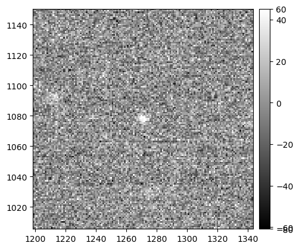

```python
display = afwDisplay.Display()
display.scale('linear', 'zscale')
display.image(exposure.image)
plt.show()
```

> **Figure 1**: Science image extension of the `ExposureF` cutout for the first g-band observation of Rubin discovery 2024 WP103.

### 3.2. Generate cutout in different format

Now, return the cutout in `ImageF` format instead of `ExposureF`. This is the same procedure, except one calls `get_adhocservice_by_id("cutout-sync")` instead of `get_adhocservice_by_id("cutout-sync-exposure")`, and the return format will be like a fits file. Use astropy and matplotlib tools to plot instead of LSST pipeline tools.

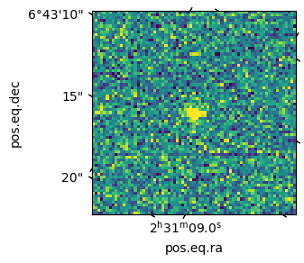

```python
sci, scihdul = get_cutout(dl_result, tab_g['ra'][0], tab_g['dec'][0], get_pyvo_auth(), fov)

sci_header = scihdul[1].header
scidata = scihdul[1].data

plt.subplot(1, 2, 1, projection=WCS(scihdul[1].header))
plt.imshow(scidata, origin='lower', vmin=np.nanpercentile(scidata, 1),
           vmax=np.nanpercentile(scidata, 99))
```

> **Figure 2**: `ImageF` cutout format for the first g-band observtion of Rubin discovery 2024 WP103.

## 4. Create single-epoch triplet stamps

### 4.1. Query ObsCore table for all visits

To create a triplet stamp (i.e., the science, template, and difference images) for the first g-band detection of the Solar System target, query the ObsCore table for the `visit` (`science`), `template_coadd`, and `difference` images for the target. Rather than restricting the queries to the first detections, return all visit, template, and difference images for the target. This will avoid the need to run the queries again in Section 5 below when bulk image stamps are generated.

As described in Section 3.1 above, use the `visit` and `detector` parameters in the image query to return images containing the Solar System target.

Set the `visit` and `detector` conditions that cutout queries must satisfy to match those for each g-band detection of the Solar System object in the `tab_g` table. Returned visit images must match both the `visit` and `detector` for each detection.

```python
pointings = []
for row in tab_g:
    pointings.append((row['visit'], row['detector']))

pointing_conditions = []

for visit, detector in pointings:
    cond = f"(lsst_visit = {visit} AND lsst_detector = {detector})"
    pointing_conditions.append(cond)

pointings_sql = " OR ".join(pointing_conditions)
```

Build the query for the full list of visit images for the Solar System object, matching both the `visit` and `detector` for each detection. Sort the returned list of visit images by time.

```python
query = f"""
SELECT dataproduct_type, dataproduct_subtype, calib_level, lsst_band, em_min, em_max,
       lsst_tract, lsst_patch, lsst_filter, lsst_visit, lsst_detector, t_exptime, t_min, t_max,
       s_ra, s_dec, s_fov, obs_id, obs_collection, o_ucd, facility_name, instrument_name,
       obs_title, s_region, access_url, access_format
FROM ivoa.ObsCore
WHERE obs_collection = 'LSST.DP1'
  AND calib_level = 2
  AND dataproduct_type = 'image'
  AND instrument_name = 'LSSTComCam'
  AND dataproduct_subtype = 'lsst.visit_image'
  AND ({pointings_sql})
ORDER BY t_min ASC
"""
```

Execute the query. Store the results in a table called `scitab`.

```python
job = service.submit_job(query)
job.run()
job.wait(phases=['COMPLETED', 'ERROR'])
if job.phase == 'ERROR':
    job.raise_if_error()
scitab = job.fetch_result()
scitab.to_table()
```

*Table length=9*

| dataproduct_type object | dataproduct_subtype object | calib_level int32 | lsst_band object | em_min m float64 | em_max m float64 | lsst_tract int64 | lsst_patch int64 | lsst_filter object | lsst_visit int64 | lsst_detector int64 | t_exptime s float64 | t_min d float64 | t_max d float64 | s_ra deg float64 | s_dec deg float64 | s_fov deg float64 | obs_id object | obs_collection object | o_ucd object | facility_name object | instrument_name object | obs_title object | s_region object | access_url object | access_format object |
| --- | --- | --- | --- | --- | --- | --- | --- | --- | --- | --- | --- | --- | --- | --- | --- | --- | --- | --- | --- | --- | --- | --- | --- | --- | --- |
| image | lsst.visit_image | 2 | g | 4.026e-07 | 5.483e-07 | -- | -- | g_01 | 2024112600112 | 3 | 30.0 | 60641.052733032506 | 60641.05308532407 | 37.795749255533444 | 6.654049228050561 | 0.3176848500023962 | CC_O_20241126_000112 | LSST.DP1 | phot.flux.density | Rubin:Simonyi | LSSTComCam | visit_image - g - CC_O_20241126_000112-R22_S10 2024-11-27T01:15:56.134008Z | POLYGON ICRS 37.951751 6.688922 37.757816 6.808360 37.639760 6.619084 37.833691 6.499764 | https://data.lsst.cloud/api/datalink/links?ID=ivo%3A%2F%2Forg.rubinobs%2Flsst-dp1%3Frepo%3Ddp1%26id%3D019b1977-c18e-7eec-8837-ee2e142137f1 | application/x-votable+xml;content=datalink |
| image | lsst.visit_image | 2 | g | 4.026e-07 | 5.483e-07 | -- | -- | g_01 | 2024112600115 | 3 | 30.0 | 60641.059839455884 | 60641.06019172454 | 37.83524180001764 | 6.673969161299994 | 0.3176664242054425 | CC_O_20241126_000115 | LSST.DP1 | phot.flux.density | Rubin:Simonyi | LSSTComCam | visit_image - g - CC_O_20241126_000115-R22_S10 2024-11-27T01:26:10.128988Z | POLYGON ICRS 37.991246 6.708828 37.797303 6.828267 37.679250 6.639019 37.873191 6.519696 | https://data.lsst.cloud/api/datalink/links?ID=ivo%3A%2F%2Forg.rubinobs%2Flsst-dp1%3Frepo%3Ddp1%26id%3D019b1977-ca2a-7599-832a-c39703e525ad | application/x-votable+xml;content=datalink |
| image | lsst.visit_image | 2 | g | 4.026e-07 | 5.483e-07 | -- | -- | g_01 | 2024112600118 | 0 | 30.0 | 60641.06161649293 | 60641.06196869213 | 37.931582332958406 | 6.758994226880448 | 0.3178948841948642 | CC_O_20241126_000118 | LSST.DP1 | phot.flux.density | Rubin:Simonyi | LSSTComCam | visit_image - g - CC_O_20241126_000118-R22_S00 2024-11-27T01:28:43.664989Z | POLYGON ICRS 38.087651 6.793757 37.893718 6.913432 37.775560 6.724115 37.969400 6.604585 | https://data.lsst.cloud/api/datalink/links?ID=ivo%3A%2F%2Forg.rubinobs%2Flsst-dp1%3Frepo%3Ddp1%26id%3D019b1945-bb8d-76b6-8d34-b34edda6b334 | application/x-votable+xml;content=datalink |
| image | lsst.visit_image | 2 | g | 4.026e-07 | 5.483e-07 | -- | -- | g_01 | 2024112700084 | 5 | 30.0 | 60642.05070755771 | 60642.051059907404 | 37.60090178481414 | 6.769413090260296 | 0.3177300950256694 | CC_O_20241127_000084 | LSST.DP1 | phot.flux.density | Rubin:Simonyi | LSSTComCam | visit_image - g - CC_O_20241127_000084-R22_S12 2024-11-28T01:13:01.132986Z | POLYGON ICRS 37.755665 6.809679 37.557543 6.922309 37.446171 6.729138 37.644205 6.616487 | https://data.lsst.cloud/api/datalink/links?ID=ivo%3A%2F%2Forg.rubinobs%2Flsst-dp1%3Frepo%3Ddp1%26id%3D019b1999-2821-7daf-b9c0-09e3c882ec63 | application/x-votable+xml;content=datalink |
| image | lsst.visit_image | 2 | g | 4.026e-07 | 5.483e-07 | -- | -- | g_01 | 2024112700088 | 5 | 30.0 | 60642.05297753495 | 60642.05332983796 | 37.640969646357455 | 6.789995360031279 | 0.317715650572084 | CC_O_20241127_000088 | LSST.DP1 | phot.flux.density | Rubin:Simonyi | LSSTComCam | visit_image - g - CC_O_20241127_000088-R22_S12 2024-11-28T01:16:17.259019Z | POLYGON ICRS 37.795733 6.830255 37.597607 6.942892 37.486239 6.749721 37.684278 6.637072 | https://data.lsst.cloud/api/datalink/links?ID=ivo%3A%2F%2Forg.rubinobs%2Flsst-dp1%3Frepo%3Ddp1%26id%3D019b1999-1eec-7543-8eea-b5321f4b97b7 | application/x-votable+xml;content=datalink |
| image | lsst.visit_image | 2 | g | 4.026e-07 | 5.483e-07 | -- | -- | g_01 | 2024112700092 | 5 | 30.0 | 60642.055161446806 | 60642.05551366898 | 37.61705785136126 | 6.674054573851342 | 0.31771511237595107 | CC_O_20241127_000092 | LSST.DP1 | phot.flux.density | Rubin:Simonyi | LSSTComCam | visit_image - g - CC_O_20241127_000092-R22_S12 2024-11-28T01:19:25.949004Z | POLYGON ICRS 37.771785 6.714312 37.573703 6.826949 37.462366 6.633779 37.660357 6.521135 | https://data.lsst.cloud/api/datalink/links?ID=ivo%3A%2F%2Forg.rubinobs%2Flsst-dp1%3Frepo%3Ddp1%26id%3D019b1999-501f-7775-9518-2e47da7c58c6 | application/x-votable+xml;content=datalink |
| image | lsst.visit_image | 2 | g | 4.026e-07 | 5.483e-07 | -- | -- | g_01 | 2024112800173 | 4 | 30.0 | 60643.08815931716 | 60643.088511539354 | 37.42815925163586 | 6.769329377688846 | 0.3174988483113268 | CC_O_20241128_000173 | LSST.DP1 | phot.flux.density | Rubin:Simonyi | LSSTComCam | visit_image - g - CC_O_20241128_000173-R22_S11 2024-11-29T02:06:56.965002Z | POLYGON ICRS 37.566873 6.848262 37.346184 6.905623 37.289493 6.690356 37.510086 6.633022 | https://data.lsst.cloud/api/datalink/links?ID=ivo%3A%2F%2Forg.rubinobs%2Flsst-dp1%3Frepo%3Ddp1%26id%3D019b1989-e986-7e19-aa65-552e1ed22ad2 | application/x-votable+xml;content=datalink |
| image | lsst.visit_image | 2 | g | 4.026e-07 | 5.483e-07 | -- | -- | g_01 | 2024112800177 | 4 | 30.0 | 60643.0904762731 | 60643.09082855324 | 37.461253560207915 | 6.799537713185662 | 0.31749993202137033 | CC_O_20241128_000177 | LSST.DP1 | phot.flux.density | Rubin:Simonyi | LSSTComCam | visit_image - g - CC_O_20241128_000177-R22_S11 2024-11-29T02:10:17.149996Z | POLYGON ICRS 37.599973 6.878472 37.379276 6.935835 37.322578 6.720562 37.543188 6.663230 | https://data.lsst.cloud/api/datalink/links?ID=ivo%3A%2F%2Forg.rubinobs%2Flsst-dp1%3Frepo%3Ddp1%26id%3D019b1989-df7b-7d70-b6eb-d4988e35681c | application/x-votable+xml;content=datalink |
| image | lsst.visit_image | 2 | g | 4.026e-07 | 5.483e-07 | -- | -- | g_01 | 2024112800181 | 4 | 30.0 | 60643.09265355301 | 60643.09300586805 | 37.46843549716876 | 6.68145654847747 | 0.31751231026779375 | CC_O_20241128_000181 | LSST.DP1 | phot.flux.density | Rubin:Simonyi | LSSTComCam | visit_image - g - CC_O_20241128_000181-R22_S11 2024-11-29T02:13:25.266980Z | POLYGON ICRS 37.607125 6.760401 37.386474 6.817755 37.329792 6.602476 37.550347 6.545141 | https://data.lsst.cloud/api/datalink/links?ID=ivo%3A%2F%2Forg.rubinobs%2Flsst-dp1%3Frepo%3Ddp1%26id%3D019b1989-ef6e-7020-874d-d441f0d73cba | application/x-votable+xml;content=datalink |

Use the SIA service to search for `template_coadd` (calibration level 3) images that overlap a search `circle` centered on the ra and dec coordinates for each detection of the Solar System object (in `tab_g`). Filter the results for g-band `template_coadd` images to match the band of the `visit` images. Store the results in a table called `reftab`.

Assert that the number of returned `template_coadd` images equals the number of visit images. If the number of returned template images does not match the number of visits, the visit images cannot be rotated to align with the template images in Section 4.3 below.

```python
circle = (tab_g['ra'][0], tab_g['dec'][0], 0.001)

results = sia_service.search(pos=circle, calib_level=3)

lvl3_table = results.to_table()

num_visits = len(scitab['t_max'])
print('number of visits:', num_visits)
for i in range(num_visits-1):
    circle = (tab_g['ra'][i+1], tab_g['dec'][i+1], 0.001)

    results = sia_service.search(pos=circle, calib_level=3)

    tmp_table = results.to_table()

    lvl3_table = np.append(lvl3_table, tmp_table, axis=0)

tx = np.where((lvl3_table['dataproduct_subtype'] == 'lsst.template_coadd')
              & (lvl3_table['lsst_band'] == 'g'))[0]
reftab = pd.DataFrame(lvl3_table[tx])

assert len(reftab) == num_visits

reftab
```

```
number of visits: 9
```

|  | dataproduct_type | dataproduct_subtype | facility_name | calib_level | target_name | obs_id | obs_collection | obs_publisher_did | access_url | access_format | ... | lsst_detector | lsst_tract | lsst_patch | lsst_band | lsst_filter | obs_title | s_ra | s_dec | s_fov | s_region |
| --- | --- | --- | --- | --- | --- | --- | --- | --- | --- | --- | --- | --- | --- | --- | --- | --- | --- | --- | --- | --- | --- |
| 0 | image | lsst.template_coadd | Rubin:Simonyi | 3 |  | lsst_cells_v1-10463-52 | LSST.DP1 | ivo://org.rubinobs/usdac/lsst-dp1?repo=dp1&id=... | https://data.lsst.cloud/api/datalink/links?ID=... | application/x-votable+xml;content=datalink | ... | 0 | 10463 | 52 | g |  | template_coadd - g - tract=10463 patch=52 | 37.763960 | 6.777396 | 0.267120 | POLYGON ICRS 37.668794 6.683025 37.858964 6.68... |
| 1 | image | lsst.template_coadd | Rubin:Simonyi | 3 |  | lsst_cells_v1-10463-52 | LSST.DP1 | ivo://org.rubinobs/usdac/lsst-dp1?repo=dp1&id=... | https://data.lsst.cloud/api/datalink/links?ID=... | application/x-votable+xml;content=datalink | ... | 0 | 10463 | 52 | g |  | template_coadd - g - tract=10463 patch=52 | 37.763960 | 6.777396 | 0.267120 | POLYGON ICRS 37.668794 6.683025 37.858964 6.68... |
| 2 | image | lsst.template_coadd | Rubin:Simonyi | 3 |  | lsst_cells_v1-10463-52 | LSST.DP1 | ivo://org.rubinobs/usdac/lsst-dp1?repo=dp1&id=... | https://data.lsst.cloud/api/datalink/links?ID=... | application/x-votable+xml;content=datalink | ... | 0 | 10463 | 52 | g |  | template_coadd - g - tract=10463 patch=52 | 37.763960 | 6.777396 | 0.267120 | POLYGON ICRS 37.668794 6.683025 37.858964 6.68... |
| 3 | image | lsst.template_coadd | Rubin:Simonyi | 3 |  | lsst_cells_v1-10463-53 | LSST.DP1 | ivo://org.rubinobs/usdac/lsst-dp1?repo=dp1&id=... | https://data.lsst.cloud/api/datalink/links?ID=... | application/x-votable+xml;content=datalink | ... | 0 | 10463 | 53 | g |  | template_coadd - g - tract=10463 patch=53 | 37.596127 | 6.777511 | 0.267126 | POLYGON ICRS 37.500990 6.683107 37.691167 6.68... |
| 4 | image | lsst.template_coadd | Rubin:Simonyi | 3 |  | lsst_cells_v1-10463-53 | LSST.DP1 | ivo://org.rubinobs/usdac/lsst-dp1?repo=dp1&id=... | https://data.lsst.cloud/api/datalink/links?ID=... | application/x-votable+xml;content=datalink | ... | 0 | 10463 | 53 | g |  | template_coadd - g - tract=10463 patch=53 | 37.596127 | 6.777511 | 0.267126 | POLYGON ICRS 37.500990 6.683107 37.691167 6.68... |
| 5 | image | lsst.template_coadd | Rubin:Simonyi | 3 |  | lsst_cells_v1-10463-53 | LSST.DP1 | ivo://org.rubinobs/usdac/lsst-dp1?repo=dp1&id=... | https://data.lsst.cloud/api/datalink/links?ID=... | application/x-votable+xml;content=datalink | ... | 0 | 10463 | 53 | g |  | template_coadd - g - tract=10463 patch=53 | 37.596127 | 6.777511 | 0.267126 | POLYGON ICRS 37.500990 6.683107 37.691167 6.68... |
| 6 | image | lsst.template_coadd | Rubin:Simonyi | 3 |  | lsst_cells_v1-10463-54 | LSST.DP1 | ivo://org.rubinobs/usdac/lsst-dp1?repo=dp1&id=... | https://data.lsst.cloud/api/datalink/links?ID=... | application/x-votable+xml;content=datalink | ... | 0 | 10463 | 54 | g |  | template_coadd - g - tract=10463 patch=54 | 37.428290 | 6.777568 | 0.267128 | POLYGON ICRS 37.333183 6.683131 37.523364 6.68... |
| 7 | image | lsst.template_coadd | Rubin:Simonyi | 3 |  | lsst_cells_v1-10463-54 | LSST.DP1 | ivo://org.rubinobs/usdac/lsst-dp1?repo=dp1&id=... | https://data.lsst.cloud/api/datalink/links?ID=... | application/x-votable+xml;content=datalink | ... | 0 | 10463 | 54 | g |  | template_coadd - g - tract=10463 patch=54 | 37.428290 | 6.777568 | 0.267128 | POLYGON ICRS 37.333183 6.683131 37.523364 6.68... |
| 8 | image | lsst.template_coadd | Rubin:Simonyi | 3 |  | lsst_cells_v1-10463-54 | LSST.DP1 | ivo://org.rubinobs/usdac/lsst-dp1?repo=dp1&id=... | https://data.lsst.cloud/api/datalink/links?ID=... | application/x-votable+xml;content=datalink | ... | 0 | 10463 | 54 | g |  | template_coadd - g - tract=10463 patch=54 | 37.428290 | 6.777568 | 0.267128 | POLYGON ICRS 37.333183 6.683131 37.523364 6.68... |

9 rows × 37 columns

Similar to the `visit_images` above, build the query to search for (calibration level 3) `difference_images` that overlap the full list of visit images for the Solar System object, matching the `visit` and `detector` conditions for each detection as defined in `pointings_sql` above. Sort by time to match the visit images (`scitab`) above.

```python
query = f"""
SELECT dataproduct_type, dataproduct_subtype, calib_level, lsst_band, em_min, em_max,
       lsst_tract, lsst_patch, lsst_filter, lsst_visit, lsst_detector, t_exptime, t_min, t_max,
       s_ra, s_dec, s_fov, obs_id, obs_collection, o_ucd, facility_name, instrument_name,
       obs_title, s_region, access_url, access_format
FROM ivoa.ObsCore
WHERE obs_collection = 'LSST.DP1'
  AND calib_level = 3
  AND dataproduct_type = 'image'
  AND instrument_name = 'LSSTComCam'
  AND dataproduct_subtype = 'lsst.difference_image'
  AND ({pointings_sql})
ORDER BY t_min ASC
"""
```

Execute the query. Store the results in a table called `difftab`.

```python
job = service.submit_job(query)
job.run()
job.wait(phases=['COMPLETED', 'ERROR'])
if job.phase == 'ERROR':
    job.raise_if_error()
difftab = job.fetch_result()
difftab.to_table()
```

*Table length=9*

| dataproduct_type object | dataproduct_subtype object | calib_level int32 | lsst_band object | em_min m float64 | em_max m float64 | lsst_tract int64 | lsst_patch int64 | lsst_filter object | lsst_visit int64 | lsst_detector int64 | t_exptime s float64 | t_min d float64 | t_max d float64 | s_ra deg float64 | s_dec deg float64 | s_fov deg float64 | obs_id object | obs_collection object | o_ucd object | facility_name object | instrument_name object | obs_title object | s_region object | access_url object | access_format object |
| --- | --- | --- | --- | --- | --- | --- | --- | --- | --- | --- | --- | --- | --- | --- | --- | --- | --- | --- | --- | --- | --- | --- | --- | --- | --- |
| image | lsst.difference_image | 3 | g | 4.026e-07 | 5.483e-07 | -- | -- | g_01 | 2024112600112 | 3 | 30.0 | 60641.052733032506 | 60641.05308532407 | 37.795749255533444 | 6.654049228050561 | 0.3176848500023962 | CC_O_20241126_000112 | LSST.DP1 | phot.flux.density | Rubin:Simonyi | LSSTComCam | difference_image - g - CC_O_20241126_000112-R22_S10 2024-11-27T01:15:56.134008Z | POLYGON ICRS 37.951751 6.688922 37.757816 6.808360 37.639760 6.619084 37.833691 6.499764 | https://data.lsst.cloud/api/datalink/links?ID=ivo%3A%2F%2Forg.rubinobs%2Flsst-dp1%3Frepo%3Ddp1%26id%3D019b1977-cb94-76a4-ac6c-430f0df4b35e | application/x-votable+xml;content=datalink |
| image | lsst.difference_image | 3 | g | 4.026e-07 | 5.483e-07 | -- | -- | g_01 | 2024112600115 | 3 | 30.0 | 60641.059839455884 | 60641.06019172454 | 37.83524180001764 | 6.673969161299994 | 0.3176664242054425 | CC_O_20241126_000115 | LSST.DP1 | phot.flux.density | Rubin:Simonyi | LSSTComCam | difference_image - g - CC_O_20241126_000115-R22_S10 2024-11-27T01:26:10.128988Z | POLYGON ICRS 37.991246 6.708828 37.797303 6.828267 37.679250 6.639019 37.873191 6.519696 | https://data.lsst.cloud/api/datalink/links?ID=ivo%3A%2F%2Forg.rubinobs%2Flsst-dp1%3Frepo%3Ddp1%26id%3D019b1977-d42f-77f6-abf6-bf720ce0a5fe | application/x-votable+xml;content=datalink |
| image | lsst.difference_image | 3 | g | 4.026e-07 | 5.483e-07 | -- | -- | g_01 | 2024112600118 | 0 | 30.0 | 60641.06161649293 | 60641.06196869213 | 37.931582332958406 | 6.758994226880448 | 0.3178948841948642 | CC_O_20241126_000118 | LSST.DP1 | phot.flux.density | Rubin:Simonyi | LSSTComCam | difference_image - g - CC_O_20241126_000118-R22_S00 2024-11-27T01:28:43.664989Z | POLYGON ICRS 38.087651 6.793757 37.893718 6.913432 37.775560 6.724115 37.969400 6.604585 | https://data.lsst.cloud/api/datalink/links?ID=ivo%3A%2F%2Forg.rubinobs%2Flsst-dp1%3Frepo%3Ddp1%26id%3D019b1945-c5cd-73b4-8551-a65e768c111f | application/x-votable+xml;content=datalink |
| image | lsst.difference_image | 3 | g | 4.026e-07 | 5.483e-07 | -- | -- | g_01 | 2024112700084 | 5 | 30.0 | 60642.05070755771 | 60642.051059907404 | 37.60090178481414 | 6.769413090260296 | 0.3177300950256694 | CC_O_20241127_000084 | LSST.DP1 | phot.flux.density | Rubin:Simonyi | LSSTComCam | difference_image - g - CC_O_20241127_000084-R22_S12 2024-11-28T01:13:01.132986Z | POLYGON ICRS 37.755665 6.809679 37.557543 6.922309 37.446171 6.729138 37.644205 6.616487 | https://data.lsst.cloud/api/datalink/links?ID=ivo%3A%2F%2Forg.rubinobs%2Flsst-dp1%3Frepo%3Ddp1%26id%3D019b1999-325c-762c-81f0-49def7cf9459 | application/x-votable+xml;content=datalink |
| image | lsst.difference_image | 3 | g | 4.026e-07 | 5.483e-07 | -- | -- | g_01 | 2024112700088 | 5 | 30.0 | 60642.05297753495 | 60642.05332983796 | 37.640969646357455 | 6.789995360031279 | 0.317715650572084 | CC_O_20241127_000088 | LSST.DP1 | phot.flux.density | Rubin:Simonyi | LSSTComCam | difference_image - g - CC_O_20241127_000088-R22_S12 2024-11-28T01:16:17.259019Z | POLYGON ICRS 37.795733 6.830255 37.597607 6.942892 37.486239 6.749721 37.684278 6.637072 | https://data.lsst.cloud/api/datalink/links?ID=ivo%3A%2F%2Forg.rubinobs%2Flsst-dp1%3Frepo%3Ddp1%26id%3D019b1999-292c-73b5-9c93-11cc7c2e0b09 | application/x-votable+xml;content=datalink |
| image | lsst.difference_image | 3 | g | 4.026e-07 | 5.483e-07 | -- | -- | g_01 | 2024112700092 | 5 | 30.0 | 60642.055161446806 | 60642.05551366898 | 37.61705785136126 | 6.674054573851342 | 0.31771511237595107 | CC_O_20241127_000092 | LSST.DP1 | phot.flux.density | Rubin:Simonyi | LSSTComCam | difference_image - g - CC_O_20241127_000092-R22_S12 2024-11-28T01:19:25.949004Z | POLYGON ICRS 37.771785 6.714312 37.573703 6.826949 37.462366 6.633779 37.660357 6.521135 | https://data.lsst.cloud/api/datalink/links?ID=ivo%3A%2F%2Forg.rubinobs%2Flsst-dp1%3Frepo%3Ddp1%26id%3D019b1999-5a34-7475-8443-e97a968c6c41 | application/x-votable+xml;content=datalink |
| image | lsst.difference_image | 3 | g | 4.026e-07 | 5.483e-07 | -- | -- | g_01 | 2024112800173 | 4 | 30.0 | 60643.08815931716 | 60643.088511539354 | 37.42815925163586 | 6.769329377688846 | 0.3174988483113268 | CC_O_20241128_000173 | LSST.DP1 | phot.flux.density | Rubin:Simonyi | LSSTComCam | difference_image - g - CC_O_20241128_000173-R22_S11 2024-11-29T02:06:56.965002Z | POLYGON ICRS 37.566873 6.848262 37.346184 6.905623 37.289493 6.690356 37.510086 6.633022 | https://data.lsst.cloud/api/datalink/links?ID=ivo%3A%2F%2Forg.rubinobs%2Flsst-dp1%3Frepo%3Ddp1%26id%3D019b1989-f3a5-7fac-b994-5b9c5d3947b7 | application/x-votable+xml;content=datalink |
| image | lsst.difference_image | 3 | g | 4.026e-07 | 5.483e-07 | -- | -- | g_01 | 2024112800177 | 4 | 30.0 | 60643.0904762731 | 60643.09082855324 | 37.461253560207915 | 6.799537713185662 | 0.31749993202137033 | CC_O_20241128_000177 | LSST.DP1 | phot.flux.density | Rubin:Simonyi | LSSTComCam | difference_image - g - CC_O_20241128_000177-R22_S11 2024-11-29T02:10:17.149996Z | POLYGON ICRS 37.599973 6.878472 37.379276 6.935835 37.322578 6.720562 37.543188 6.663230 | https://data.lsst.cloud/api/datalink/links?ID=ivo%3A%2F%2Forg.rubinobs%2Flsst-dp1%3Frepo%3Ddp1%26id%3D019b1989-e9a0-70bd-8b5a-857b2d644c9e | application/x-votable+xml;content=datalink |
| image | lsst.difference_image | 3 | g | 4.026e-07 | 5.483e-07 | -- | -- | g_01 | 2024112800181 | 4 | 30.0 | 60643.09265355301 | 60643.09300586805 | 37.46843549716876 | 6.68145654847747 | 0.31751231026779375 | CC_O_20241128_000181 | LSST.DP1 | phot.flux.density | Rubin:Simonyi | LSSTComCam | difference_image - g - CC_O_20241128_000181-R22_S11 2024-11-29T02:13:25.266980Z | POLYGON ICRS 37.607125 6.760401 37.386474 6.817755 37.329792 6.602476 37.550347 6.545141 | https://data.lsst.cloud/api/datalink/links?ID=ivo%3A%2F%2Forg.rubinobs%2Flsst-dp1%3Frepo%3Ddp1%26id%3D019b1989-f97d-7d2b-ba37-d6bd6b9679dd | application/x-votable+xml;content=datalink |

Print the date of the earliest (g-band) image for which bulk image stamps will be retrieved.

```python
print('begin date:', scitab['t_max'][0], difftab['t_max'][0])
print('end date:', scitab['t_max'][len(scitab['t_max'])-1])
print('number of visits:', len(scitab['t_max']))
```

```
begin date: 60641.05308532407 60641.05308532407
end date: 60643.09300586805
number of visits: 9
```

### 4.2. Retrieve stamps

Retrieve the `access_url` from the query (or datalink) which points to the image location on the remote server for the first entries in each of the visit (`scitab`), template (`reftab`), and difference (`difftab`) image table results. The datalinks stored as `dl_result`s below are in a format that can be used by the IVOA tools to generate the cutouts. The image products being retrieved for the science and difference images correspond to the earliest images.

```python
dl_result_sci = DatalinkResults.from_result_url(scitab['access_url'][0], session=get_pyvo_auth())

dl_result_ref = DatalinkResults.from_result_url(reftab['access_url'][0], session=get_pyvo_auth())

dl_result_diff = DatalinkResults.from_result_url(difftab['access_url'][0], session=get_pyvo_auth())
```

Retrieve bulk image stamps with an edge size of `fov` (defined to be 0.004 degrees above). The `get_cutout` function returns both the image array (first parameter) and the corresponding Header Data Unit List (HDUL), a Python object used by astropy to contain one or more Header Data Units (HDUs) that contain astronomical image data, metadata, or tables.

```python
sci, scihdul = get_cutout(dl_result_sci, tab_g['ra'][0], tab_g['dec'][0], get_pyvo_auth(), fov)
ref, refhdul = get_cutout(dl_result_ref, tab_g['ra'][0], tab_g['dec'][0], get_pyvo_auth(), fov)
diff, diffhdul = get_cutout(dl_result_diff, tab_g['ra'][0], tab_g['dec'][0], get_pyvo_auth(), fov)
```

First, visualize the cutouts of the science, template, and difference images for the earliest g-band images by displaying them side by side.

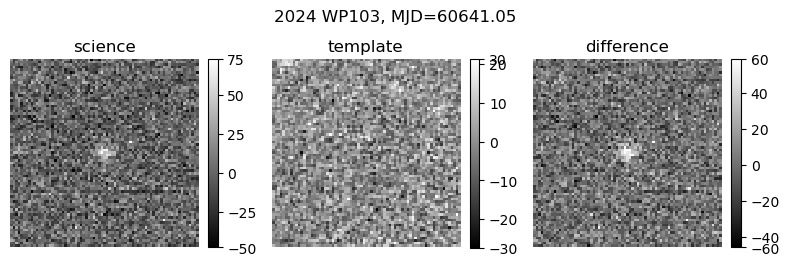

```python
fig, ax = plt.subplots(1, 3, figsize=(8, 3))
plt.sca(ax[0])
display1 = afwDisplay.Display(frame=fig)
display1.scale('linear', 'zscale')
display1.mtv(sci)
plt.title('science')
plt.sca(ax[1])
display2 = afwDisplay.Display(frame=fig)
display2.scale('linear', 'zscale')
display2.mtv(ref)
plt.title('template')
plt.sca(ax[2])
display3 = afwDisplay.Display(frame=fig)
display3.scale('linear', 'zscale')
display3.mtv(diff)
ax[0].set_axis_off()
ax[1].set_axis_off()
ax[2].set_axis_off()
plt.title('difference')
plt.tight_layout()
fig.suptitle(str(mpcDesignation)+', MJD='+str(np.round(scitab['t_max'][0], 2)))

plt.show()
```

> **Figure 3**: The cutout triplet for the first g-band detection of this Solar System object, Rubin discovery 2024 WP103.

### 4.3. Rotate visit and difference images

As Figure 3 shows, visit images are not aligned with the template image (North up, East left) since they are taken at many different telescope orientations. This section demonstrates how to align the visit image to match the orientation of the template and difference cutouts using the `reproject` python package. `reproject` requires the world coordinate system (WCS) of the existing and desired coordinate systems, and the image pixels of the image to reproject, in order to perform the calculation.

The cell below extracts these from the HUDL. The structure of the ImageF object returned by the cutout service has two HDUL extensions. The extension 0 contains a primary header of telescope metadata and no image pixels, while the extension 1 contains the science header and the science image pixels.

```python
sci_primary_header = scihdul[0].header
sci_hdu = scihdul[1]
sci_header = scihdul[1].header
scidata = scihdul[1].data
sciwcs = WCS(scihdul[1].header)

ref_primary_header = refhdul[0].header
ref_hdu = refhdul[1]
ref_header = refhdul[1].header
refdata = refhdul[1].data
refwcs = WCS(refhdul[1].header)

diff_primary_header = diffhdul[0].header
diff_hdu = diffhdul[1]
diff_header = diffhdul[1].header
diffdata = diffhdul[1].data
diffwcs = WCS(diffhdul[1].header)
```

Use the `reproject_interp` function to put the science visit image onto the WCS of the template image.

```python
reproj_scidata, footprint = reproject_interp((scidata, sciwcs), refwcs)
reproj_diffdata, footprint = reproject_interp((diffdata, diffwcs), refwcs)
```

Plot the reprojected science visit image and reprojected difference image together with the template image to compare.

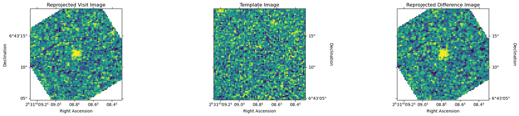

```python
fig = plt.figure(figsize=(20, 12))

ax1 = fig.add_subplot(1, 3, 1, projection=WCS(ref_hdu.header))
ax1.imshow(reproj_scidata, origin='lower', vmin=np.nanpercentile(reproj_scidata, 1),
           vmax=np.nanpercentile(reproj_scidata, 99))
ax1.coords['ra'].set_axislabel('Right Ascension')
ax1.coords['dec'].set_axislabel('Declination')
ax1.set_title('Reprojected Visit Image')

ax2 = fig.add_subplot(1, 3, 2, projection=WCS(ref_hdu.header))
ax2.imshow(refdata, origin='lower', vmin=np.nanpercentile(refdata, 1),
           vmax=np.nanpercentile(refdata, 99))
ax2.coords['ra'].set_axislabel('Right Ascension')
ax2.coords['dec'].set_axislabel('Declination')
ax2.coords['dec'].set_axislabel_position('r')
ax2.coords['dec'].set_ticklabel_position('r')
ax2.set_title('Template Image')

ax3 = fig.add_subplot(1, 3, 3, projection=WCS(ref_hdu.header))
ax3.imshow(reproj_diffdata, origin='lower', vmin=np.nanpercentile(reproj_diffdata, 1),
           vmax=np.nanpercentile(reproj_diffdata, 99))
ax3.coords['ra'].set_axislabel('Right Ascension')
ax3.coords['dec'].set_axislabel('Declination')
ax3.coords['dec'].set_axislabel_position('r')
ax3.coords['dec'].set_ticklabel_position('r')
ax3.set_title('Reprojected Difference Image')
plt.subplots_adjust(wspace=1.0)
plt.show()
```

> **Figure 4**: The science visit image (left) and difference image (right) after being reprojected onto the same WCS as the template image cutout (center).

## 5. Bulk image stamps

Bulk image stamps are a key visualization tool for Solar System objects. Below, retrieve many science visit image stamps and their corresponding template images at matching ra and dec coordinates to the target Solar System object. Save the image stamps as png files.

If >20 visits span the time during which the target was a DIA source, limit the number to visualize only the first 20 (to save time). The number of stamps can be limited by replacing the first line with `num_visits = 20`.

```
number of visits: 9
```

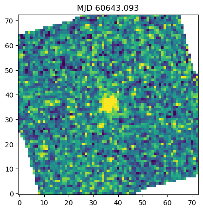

```python
num_visits = len(scitab['t_max'])
print('number of visits:', num_visits)
for i in range(num_visits):
    plt.title(f"MJD {np.round(scitab['t_max'][i], 4)}")

    dl_result_sci = DatalinkResults.from_result_url(scitab['access_url'][i],
                                                    session=get_pyvo_auth())

    sci, scihdul = get_cutout(dl_result_sci, tab_g['ra'][i], tab_g['dec'][i], get_pyvo_auth(), fov)
    sci_hdu = scihdul[1]
    sci_header = scihdul[1].header
    scidata = scihdul[1].data
    sciwcs = WCS(scihdul[1].header)

    dl_result_ref = DatalinkResults.from_result_url(reftab['access_url'][i],
                                                    session=get_pyvo_auth())

    ref, refhdul = get_cutout(dl_result_ref, tab_g['ra'][i], tab_g['dec'][i], get_pyvo_auth(), fov)
    ref_hdu = refhdul[1]
    ref_header = refhdul[1].header
    refdata = refhdul[1].data
    refwcs = WCS(refhdul[1].header)
    reproj_scidata, footprint = reproject_interp((scidata, sciwcs), refwcs)

    plt.imshow(reproj_scidata, origin='lower', vmin=np.nanpercentile(reproj_scidata, 1),
               vmax=np.nanpercentile(reproj_scidata, 99))

    figname = os.path.join(tempdir, 'stamp_' + str(i) + '.png')
    if os.path.isfile(figname):
        os.remove(figname)
    plt.savefig(figname)
```

> **Figure 5**: Final bulk science visit image saved to disk.

Visualize the bulk image stamps that were saved to disk.

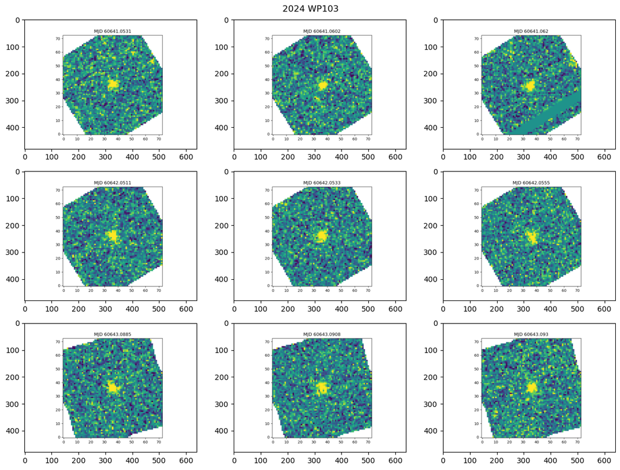

```python
fig, axes = make_subplot_grid(num_visits)
for i, ax in enumerate(axes):

    j = i
    figname = os.path.join(tempdir, 'stamp_' + str(j) + '.png')
    img = mpimg.imread(figname)

    ax.imshow(img)

plt.tight_layout()
fig.suptitle(str(mpcDesignation))
plt.subplots_adjust(top=0.95)
plt.show()
```

> **Figure 6**: Image stamps from the science visit images of the Solar System object, Rubin discovery 2024 WP103 (`ssObjectId` = 23133931615301936) in DP1, in chronological order, after being reprojected onto the same WCS as the template image.

## 6. Visualize cutouts with gif

```python
print(tempdir)
make_gif(tempdir)
dimg(data=open(tempdir+'/animation.gif', 'rb').read())
```

```
/deleted-sundays/sarahgreenstreet/dp1_308_5_temp
```

Delete tempdir created to store cutouts and gif animation and all of its contents. NOTE: This permanently deletes the directory and all of its contents.

```python
try:
    shutil.rmtree(tempdir)
    print(f"Directory '{tempdir}' and all its contents removed successfully.")
except FileNotFoundError:
    print("The directory does not exist.")
```

```
Directory '/deleted-sundays/sarahgreenstreet/dp1_308_5_temp' and all its contents removed successfully.
```

## 7. Exercise for the learner

Generate r-band cutouts for 2009 AO58 (q=2.673640 au, e=0.148635, inc=7.449680 deg, and H=16.806999).